# Deputados Federais - 2014

Leandro Carísio Fernandes

24/03/2022

## Introdução

Este relatório apresenta um panorama da composição de deputados federais na Câmara dos Deputados em 2014.

Os dados foram extraídos do [Repositório de Dados do TSE](https://www.tse.jus.br/eleicoes/estatisticas/repositorio-de-dados-eleitorais-1) e contém **18** atributos de **513** deputados.

## Da idade dos deputados eleitos em 2014

```r
# Função para cálculo da moda extraído de
# https://stackoverflow.com/questions/2547402/how-to-find-the-statistical-mode
moda <- function(x) {
  ux <- unique(x)
  ux[which.max(tabulate(match(x, ux)))]
}

idade_media = mean(deputados$Idade)
idade_mediana = median(deputados$Idade)
idade_moda = moda(deputados$Idade)
desvio_padrao = sd(deputados$Idade)
```

A média de idade dos deputados é de 50,45 anos com desvio padrão de 12 anos. A mediana e a moda da idade são bem próximas da média e valem, respectivamente, 52 e 50 anos. A figura abaixo mostra como a idade dos deputados estão distribuídas:

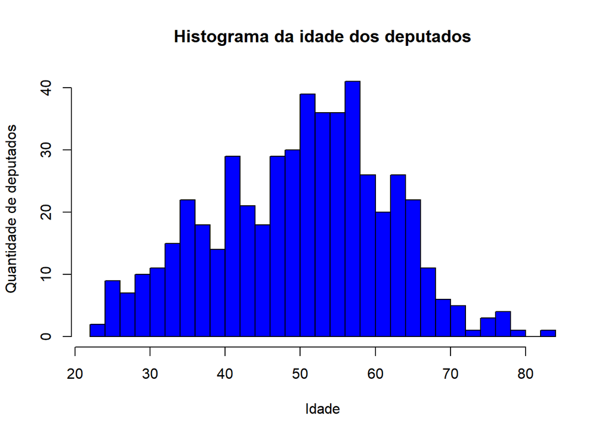

```r
hist(deputados$Idade, breaks = 30, col='blue', xlab='Idade', ylab='Quantidade de deputados', main='Histograma da idade dos deputados')
```

Uma curiosidade é que a Constituição Federal define que a idade mínima para se eleger deputado federal é de 21 anos. Entretanto, em 2014 havia 0 deputado eleito com essa idade mínima e apenas 1 deputado eleito com 22 anos de idade.

```r
total_deputadas = sum(deputados$Sexo == 'FEMININO')
total_deputados = sum(deputados$Sexo == 'MASCULINO')
```

Observa-se que a quantidade de deputadas ainda é muito menor que a de deputados. São **462** deputados e apenas **51** deputadas. Entretanto, cabe ressaltar que ambos os conjuntos apresentam média de idade semelhantes, conforme a tabela a seguir:

```r
media_idade_por_sexo = aggregate(deputados$Idade, list(deputados$Sexo), FUN=mean)
names(media_idade_por_sexo) = c('Sexo', 'Idade')
kable(media_idade_por_sexo)
```

| Sexo | Idade |
| --- | --- |
| FEMININO | 50 |
| MASCULINO | 51 |

## Quanto ao grau de instrução

```r
df_grau_instrucao = data.frame(table(deputados$Grau.de.instrucao))
df_grau_instrucao = cbind(df_grau_instrucao, 100*df_grau_instrucao$Freq/sum(df_grau_instrucao$Freq))
names(df_grau_instrucao) = c('Grau de instrução', 'Frequência', 'Porcentagem (%)')
```

Em relação ao grau de instrução, pode-se observar que a maior parte dos deputados (80%) tem ensino superior completo:

```r
kable(df_grau_instrucao)
```

| Grau de instrução | Frequência | Porcentagem (%) |
| --- | --- | --- |
| ENSINO FUNDAMENTAL COMPLETO | 10 | 1,95 |
| ENSINO FUNDAMENTAL INCOMPLETO | 4 | 0,78 |
| ENSINO MDIO INCOMPLETO | 4 | 0,78 |
| ENSINO MEDIO COMPLETO | 45 | 8,77 |
| LE E ESCREVE | 1 | 0,19 |
| SUPERIOR COMPLETO | 411 | 80,12 |
| SUPERIOR INCOMPLETO | 38 | 7,41 |

Podemos calcular também a receita média por grau de instrução e observar que não há uma relação clara entre a receita média por grau de instrução:

```r
receita_por_grau_de_escolaridade = aggregate(as.numeric(deputados$Receitas.em.2014), list(deputados$Grau.de.instrucao), FUN=mean)
names(receita_por_grau_de_escolaridade) = c('Grau de instrução', 'Receita média')
kable(receita_por_grau_de_escolaridade)
```

| Grau de instrução | Receita média |
| --- | --- |
| ENSINO FUNDAMENTAL COMPLETO | 1676919 |
| ENSINO FUNDAMENTAL INCOMPLETO | 1670446 |
| ENSINO MDIO INCOMPLETO | 1001583 |
| ENSINO MEDIO COMPLETO | 1113732 |
| LE E ESCREVE | 983590 |
| SUPERIOR COMPLETO | 1472431 |
| SUPERIOR INCOMPLETO | 1368946 |

## Quantidade de votos nominais

```r
media_votos_nominais = floor(mean(deputados$Nominais))
mediana_votos_nominais = median(deputados$Nominais)
desvio_padrao_votos_nominais = sd(deputados$Nominais)
maior_valor_voto_nominal = max(deputados$Nominais)
```

Pode-se verificar que a média dos votos nominais é de 112.403 votos e desvio padrão de 94.928 votos. A média é 11% superior a mediana de votos, que é de 101.686 votos. Isso indica a existência de valores extremos no conjunto de dados e, de fato, o maior valor do conjunto de dados (1.524.361) é cerca de 14 vezes o valor da média. Essa informação fica mais clara a partir da visualização do histograma do votos nominais recebidos pelos deputados, com alguns bins do histograma presentes acima de 1.000.000 de votos:

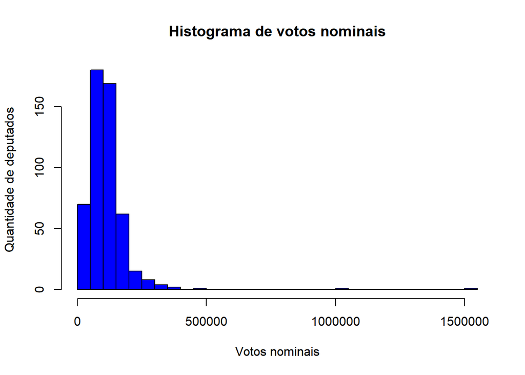

```r
hist(deputados$Nominais, breaks = 30, col='blue', xlab='Votos nominais', ylab='Quantidade de deputados', main='Histograma de votos nominais')
```

A média no país da quantidade de votos nominais recebidos traz pouca informação prática pois a votação para deputados federais é feita por unidade da Federação. Por isso, é mais interessante verificar a média por UF e dos valores mínimos e máximos recebidos por UF:

```r
media_votos_nominais_por_uf = aggregate(deputados$Nominais, list(deputados$UF), FUN=mean)
minimo_votos_nominais_por_uf = aggregate(deputados$Nominais, list(deputados$UF), FUN=min)
maximo_votos_nominais_por_uf = aggregate(deputados$Nominais, list(deputados$UF), FUN=max)
votos_nominais_por_uf = cbind(media_votos_nominais_por_uf, minimo_votos_nominais_por_uf$x, maximo_votos_nominais_por_uf$x)
names(votos_nominais_por_uf) = c('UF', 'Media', 'Menor individual', 'Maior individual')
kable(votos_nominais_por_uf)
```

| UF | Media | Menor individual | Maior individual |
| --- | --- | --- | --- |
| AC | 23205 | 17903 | 39844 |
| AL | 93577 | 53284 | 135929 |
| AM | 129262 | 71878 | 250916 |
| AP | 16633 | 10007 | 22134 |
| BA | 110148 | 39904 | 222164 |
| CE | 135853 | 80578 | 277774 |
| DF | 81586 | 32843 | 155056 |
| ES | 80258 | 45525 | 161744 |
| GO | 116079 | 77925 | 274625 |
| MA | 84074 | 50658 | 133575 |
| MG | 126458 | 46430 | 328933 |
| MS | 81650 | 54813 | 160556 |
| MT | 94693 | 62923 | 127749 |
| PA | 120799 | 63671 | 265983 |
| PB | 111558 | 63433 | 179886 |
| PE | 123302 | 28585 | 283567 |
| PI | 103616 | 80839 | 134157 |
| PR | 118591 | 59974 | 200144 |
| RJ | 86468 | 26526 | 335061 |
| RN | 124947 | 64445 | 191064 |
| RO | 43631 | 24146 | 61419 |
| RR | 14889 | 6733 | 35555 |
| RS | 117494 | 60523 | 162462 |
| SC | 133620 | 52757 | 229668 |
| SE | 10617 | 3720 | 17194 |
| SP | 171794 | 22097 | 1524361 |
| TO | 52364 | 41802 | 75934 |

## Conclusões

A base de dados utilizada nesse exercício permite retirar algumas conclusões interessantes como a idade mínima e média dos deputados, a diferença no quantitativo de deputados e deputadas, a receita média recebida por deputado eleito etc.

Apesar disso é importante ressaltar que a base não está completa, pois há informações não disponíveis (NA) para alguns atributos. Ou seja, para uma análise aprofundada seria necessário tratar esses casos, o que foge do escopo desse exercício.